# R for Data Science

Chapter 7 Exercises

Robert Kirk DeLisle

## Chapter 7 - Exploratory Data Analysis

### 7.3.4 Exercises

**1. Explore the distribution of each of the `x`, `y`, and `z` variables in `diamonds`. What do you learn? Think about a diamond and how you might decide which dimension is the length, width, and depth.**

From the plots below, there are clearly a number of outliers given the extents of the x-axis - here appear to be some 0 values and some are very large relative to the bulk of the values. Additionally, `x` and `y` appear almost perfectly correlated - are most diamonds square?

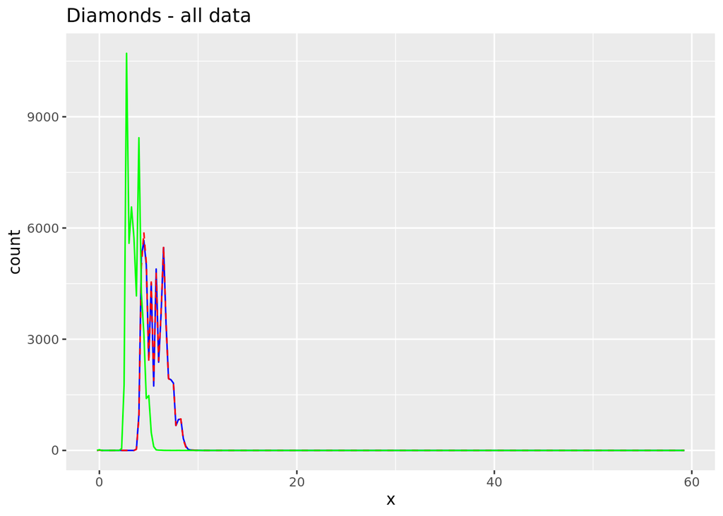

```r
ggplot(data = diamonds) +
  geom_freqpoly(mapping = aes(x), color = 'blue', binwidth = 0.25) +
  geom_freqpoly(mapping = aes(y), color = 'red', linetype = 'dashed', binwidth = 0.25) +
  geom_freqpoly(mapping = aes(z), color = 'green', binwidth = 0.25) +
  ggtitle('Diamonds - all data')
```

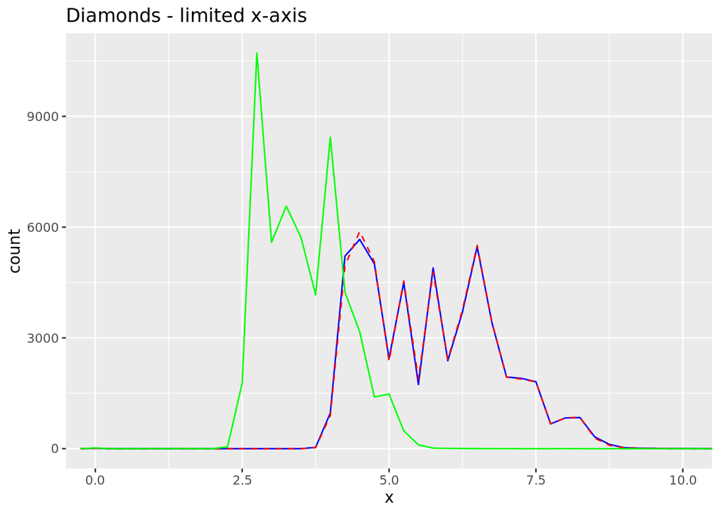

```r
ggplot(data = diamonds) +
  geom_freqpoly(mapping = aes(x), color = 'blue', binwidth = 0.25) +
  geom_freqpoly(mapping = aes(y), color = 'red', linetype = 'dashed', binwidth = 0.25) +
  geom_freqpoly(mapping = aes(z), color = 'green', binwidth = 0.25) +
  coord_cartesian(xlim = c(0,10)) +
  ggtitle('Diamonds - limited x-axis')
```

**2. Explore the distribution of `price`. Do you discover anything unusual or surprising? (Hint: carefully check the `binwidth` and make sure you try a wide range of values.)**

From the histogram, it appears there are some prices that do not occur in the dataset. Drilling deeper, it looksl like there are no diamonds in the $1450 - $1550 range. There are possibly other missng values at $4342 and $4343, but this is not as prominent as the former missing values.

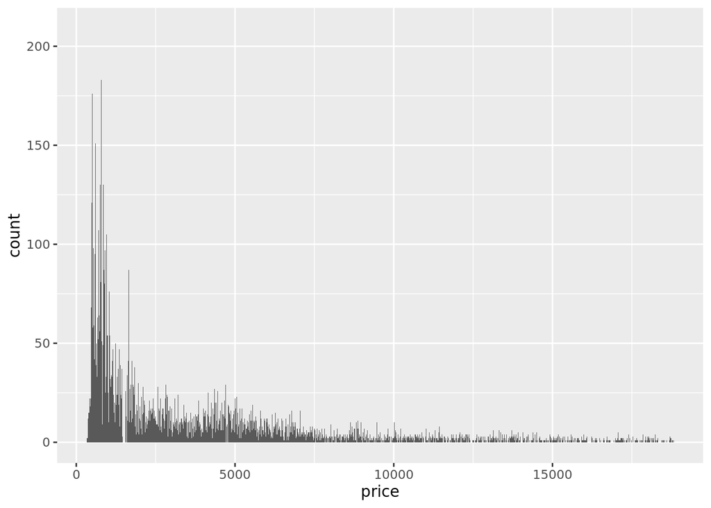

```r
ggplot(data = diamonds, mapping = aes(x=price)) +
  geom_histogram(binwidth = 2.5)
```

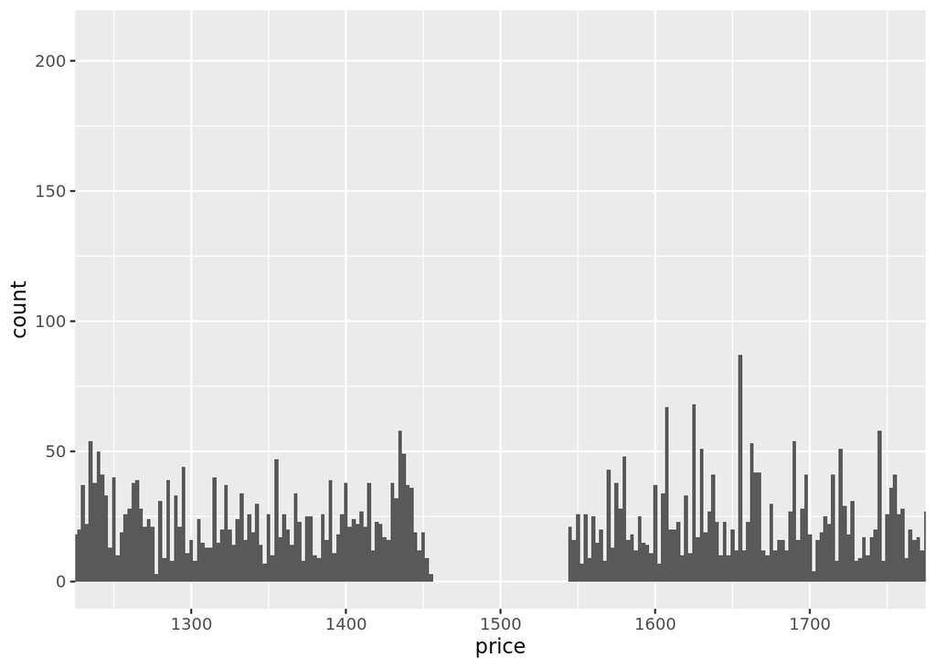

```r
ggplot(data = diamonds, mapping = aes(x=price)) +
  geom_histogram(binwidth = 2.5) +
  coord_cartesian(xlim = c(1250,1750))
```

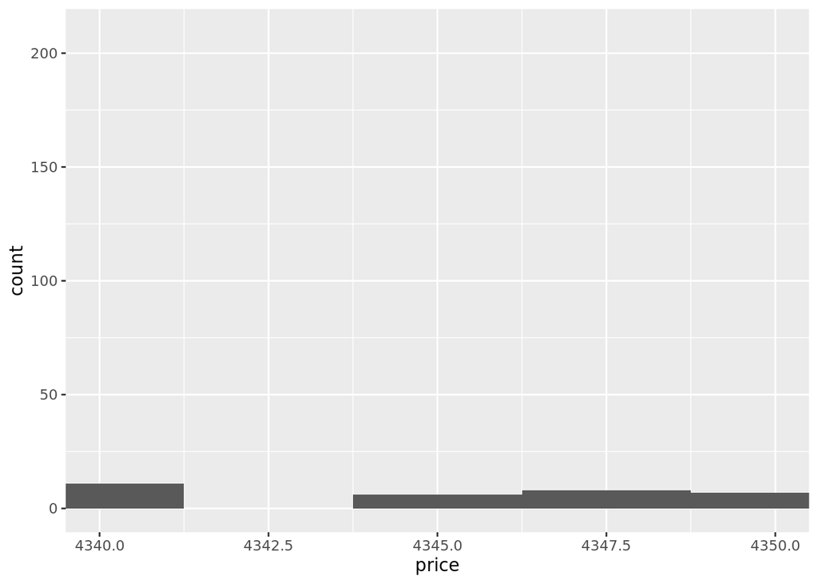

```r
ggplot(data = diamonds, mapping = aes(x=price)) +
  geom_histogram(binwidth = 2.5) +
  coord_cartesian(xlim = c(4340,4350))
```

**3. How many diamonds are 0.99 carat? How many are 1 carat? What do you think is the cause of the difference?**

There are 23 diamonds with `carat` == 0.99, and 1558 diamonds with `carat` == 1.0. This is probably due to rounding up occuring during measurement/assessment.

```r
diamonds %>%
  count(carat == 0.99)
```

```
## # A tibble: 2 x 2
##   `carat == 0.99`     n
##   <lgl>           <int>
## 1 FALSE           53917
## 2 TRUE               23
```

```r
diamonds %>%
  count(carat == 1.0)
```

```
## # A tibble: 2 x 2
##   `carat == 1`     n
##   <lgl>        <int>
## 1 FALSE        52382
## 2 TRUE          1558
```

**4. Compare and contrast `coord_cartesian()` vs `xlim()` and `ylim()` when zooming in on a histogram. What happends if you leave `binwidth` unset? What happens if you try and zoom so only half a bar shows?**

Using `xlim()` or `ylim()` will drop data that do not fit within the specified limits. `coord_cartesian()` retains all the data and just performs an optical zoom. This will affect how bins are calculated, and leaving `binwidth` unset will result in a default bin width being calculated depending on what has happened to the underlying data.

### 7.4.1 Exercises

**1. What happens to missing values in a histogram? What happens to missing values in a bar chart? Why is there a difference?**

`geom_histogram` removes missing values. If `na.rm` is `FALSE` (the default), a warning is issued with the number of observations removed. If `na.rm` is `TRUE`, observations will be removed silently. `geom_bar` will create a new category for missing values if `na.rm` is `FALSE`. If `na.rm` is `TRUE`, missing values are removed silently.

**2. What does `na.rm = TRUE` do in `mean()` and `sum()`?**

In both cases, when `na.rm == TRUE`, missing values are removed before performing the operation. If missng values are present and `na.rm == FALSE`, the operation will return `NA`.

##7.5.1.1 Exercises

**1. Use what you’ve learned to improve the visualization of the depature times of cancelled vs non-cancelled flights.**

Cancelled flights have, on average, later departure times.

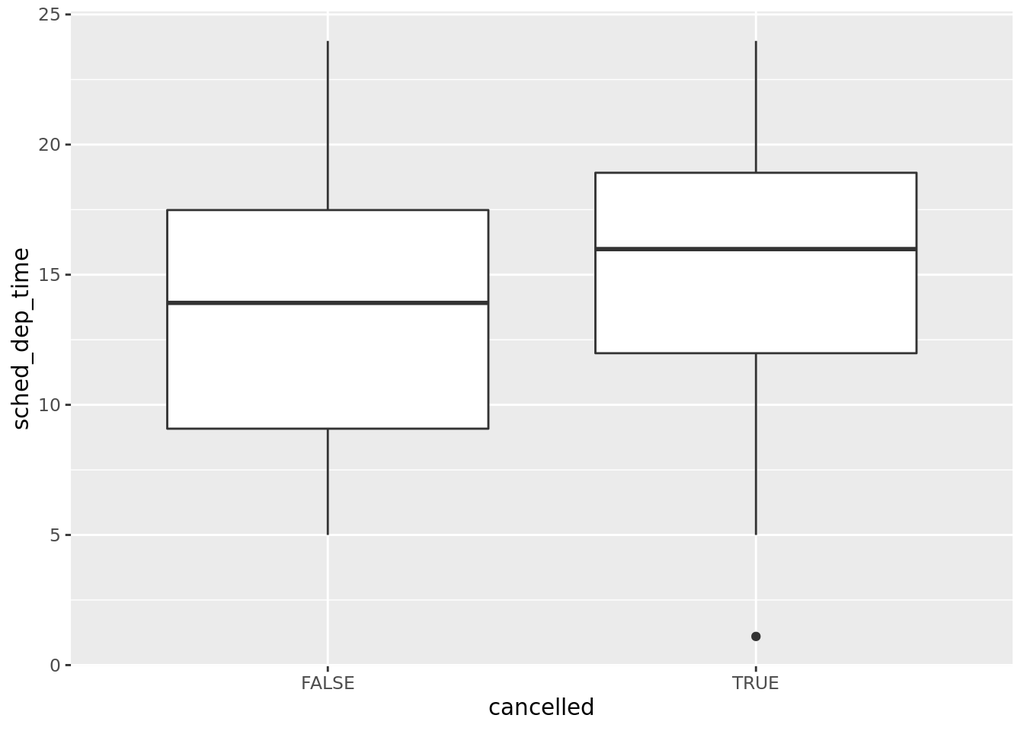

```r
nycflights13::flights %>%
  mutate(cancelled = is.na(dep_time),
         sched_hour = sched_dep_time %/% 100,
         sched_min = sched_dep_time %% 100,
         sched_dep_time = sched_hour + sched_min/60
  ) %>%
  ggplot() +
  geom_boxplot(mapping = aes(y = sched_dep_time,
                             x = cancelled))
```

**2. What variable in the diamonds dataset is most important for predicting the price of a diamond? How is that variable correlated with cut? Why does the combination of those two relationships lead to lower quality diamonds being more expensive?**

**3. Install the ggstance package, and create a horizontal boxplot. How does this compare to using coord_flip()?**

The difference lies with specifying the y-axis and flipping in `geom_boxplot` or specifying the x-axis in `geom_boxploth`.

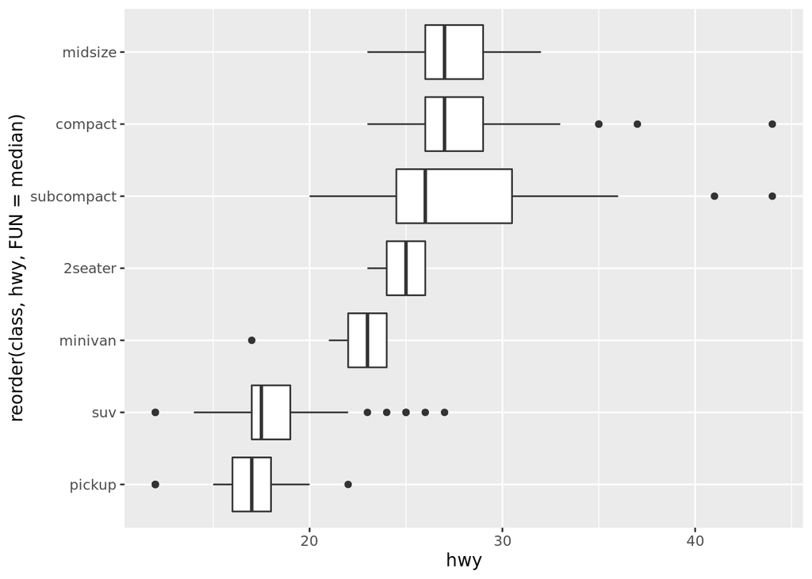

```r
ggplot(data = mpg) +
  geom_boxplot(mapping = aes(reorder(class, hwy, FUN=median), y = hwy)) +
  coord_flip()
```

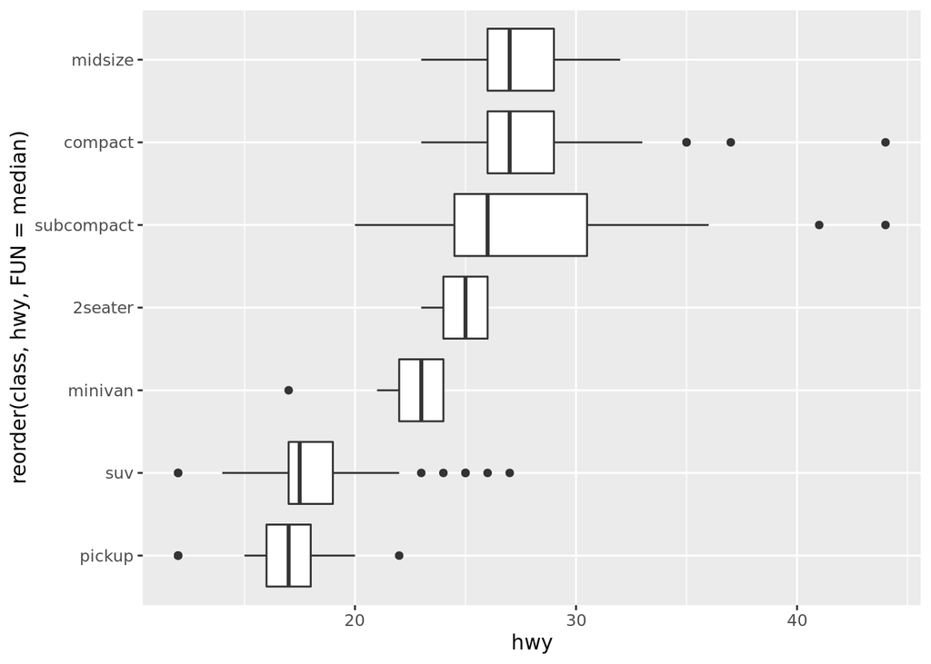

```r
ggplot(data = mpg) +
  geom_boxploth(mapping = aes(reorder(class, hwy, FUN=median), x = hwy))
```

**4. One problem with boxplots is that they were developed in an era of much smaller datasets and tend to display a prohibitively large number of “outlying values”. One approach to remedy this problem is the letter value plot. Install the lvplot package, and try using `geom_lv()` to display the distribution of price vs cut. What do you learn? How do you interpret the plots?**

I don’t really know how to interpret these.

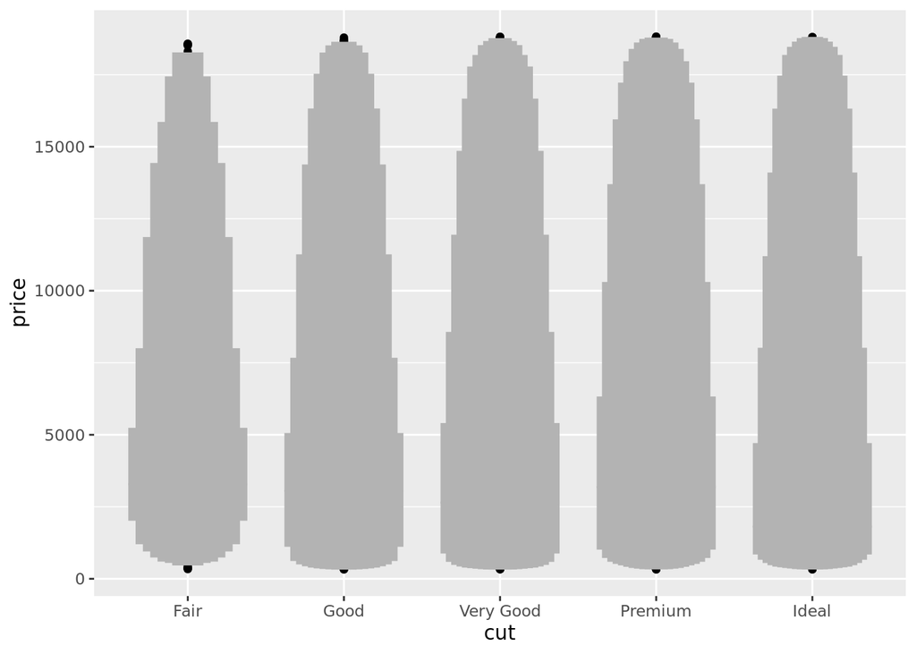

```r
ggplot(data = diamonds, mapping = aes(x = cut, y = price)) +
  geom_lv()
```

**5. Compare and contrast `geom_violin()` with a facetted `geom_histogram()`, or a coloured `geom_freqpoly()`. What are the pros and cons of each method?**

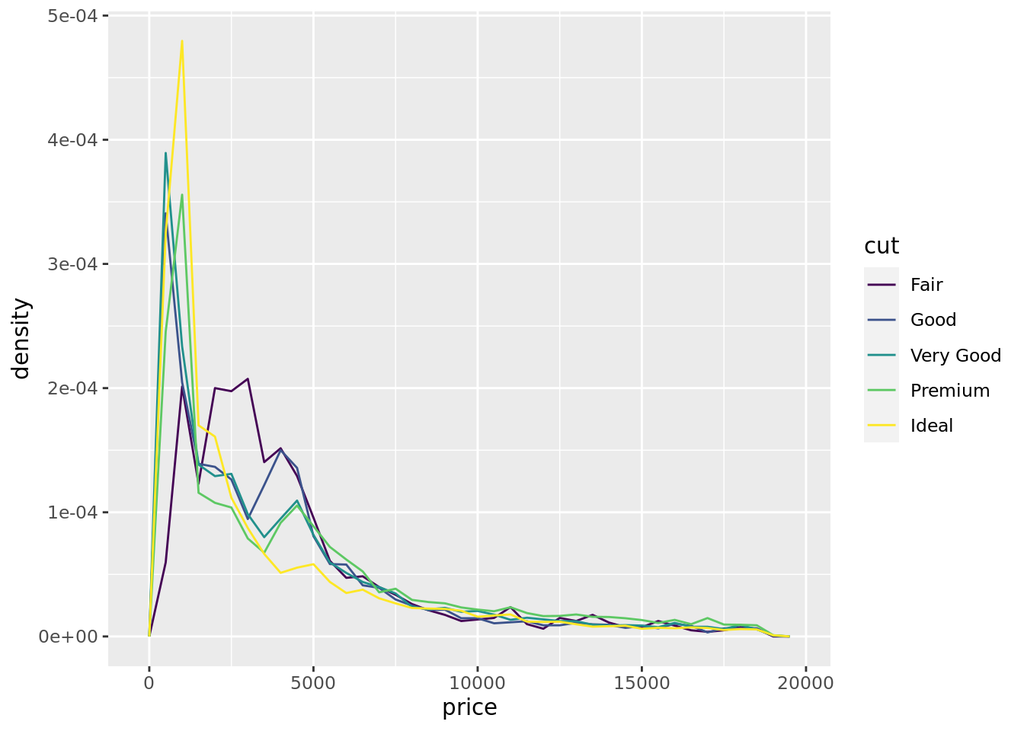

```r
ggplot(data = diamonds, mapping = aes(x = price, y = ..density..)) +
  geom_freqpoly(mapping = aes(color = cut), binwidth = 500)
```

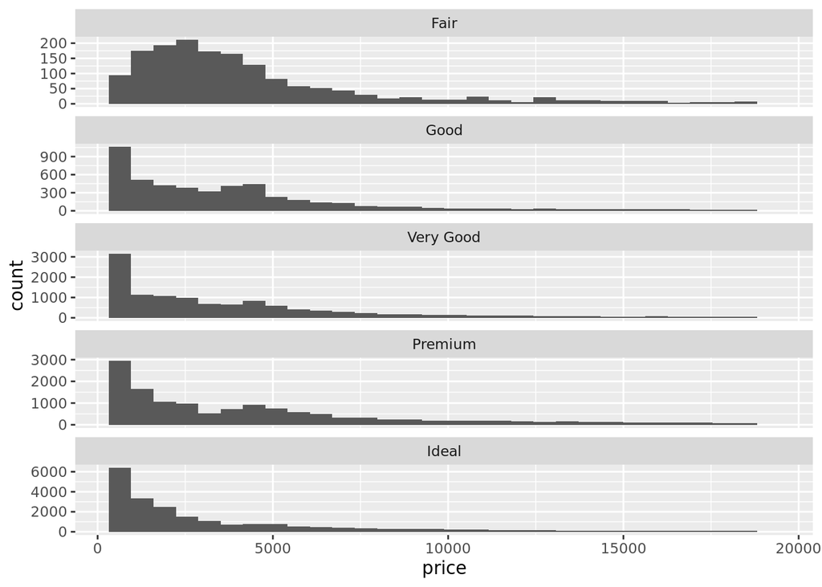

```r
ggplot(data = diamonds, mapping = aes(x = price)) +
  geom_histogram() +
  facet_wrap(~cut, ncol=1, scales = 'free_y')
```

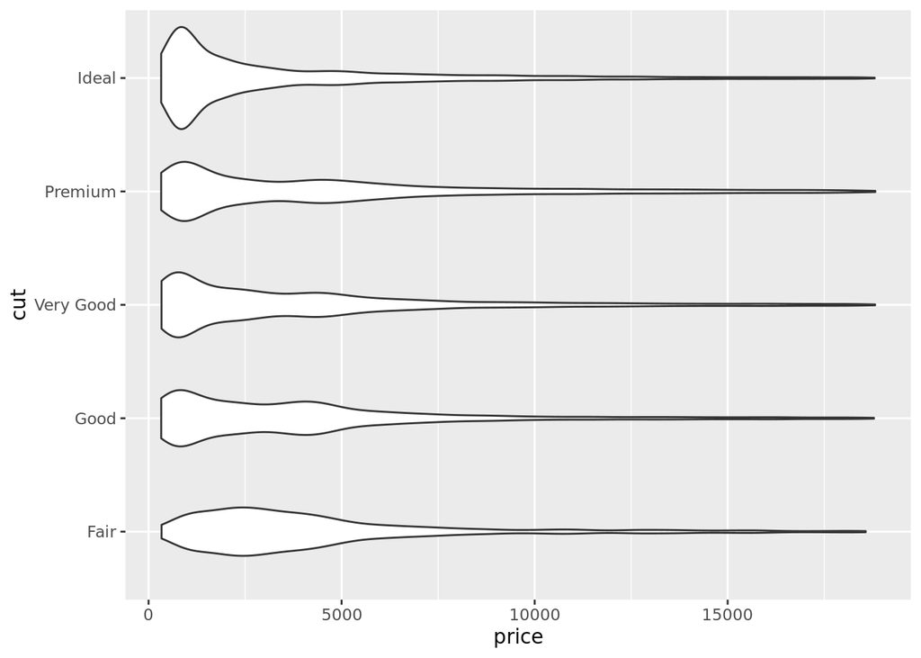

```r
ggplot(data = diamonds, mapping = aes(x = cut, y = price)) +
  geom_violin() +
  coord_flip()
```

**6. If you have a small dataset, it’s sometimes useful to use `geom_jitter()` to see the relationship between a continuous and categorical variable. The ggbeeswarm package provides a number of methods similar to `geom_jitter()`. List them and briefly describe what each one does.**

### 7.5.2.1 Exercises

**1. How could you rescale the count dataset above to more clearly show the distribution of cut within colour, or colour within cut?**

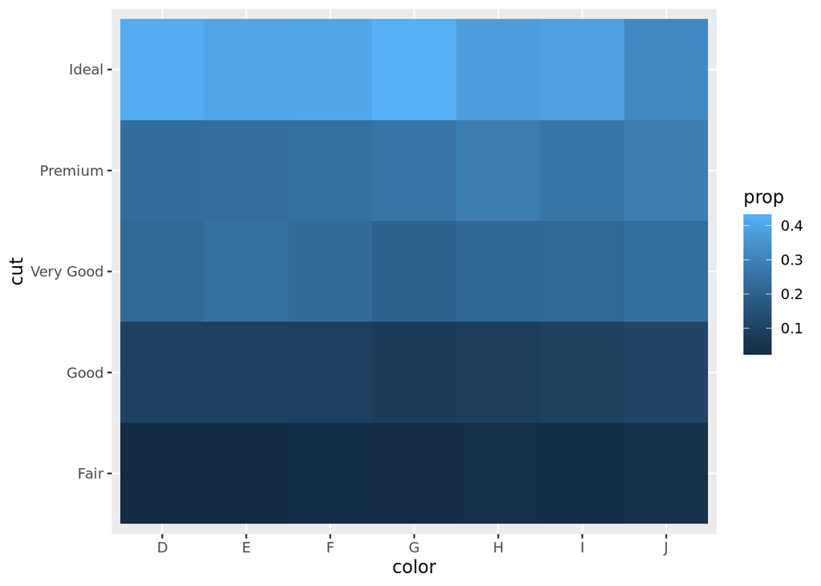

```r
diamonds %>%
  count(color, cut) %>%
  group_by(color) %>%
  mutate(prop = n / sum(n)) %>%
  ggplot(mapping = aes(x = color, y = cut)) +
    geom_tile(mapping = aes(fill = prop))
```

**2. Use `geom_tile()` together with dplyr to explore how average flight delays vary by destination and month of year. What makes the plot difficult to read? How could you improve it?**

There are a huge number of unordered values to accomodate all destinations. They should be groped by `n` or clustered in some way.

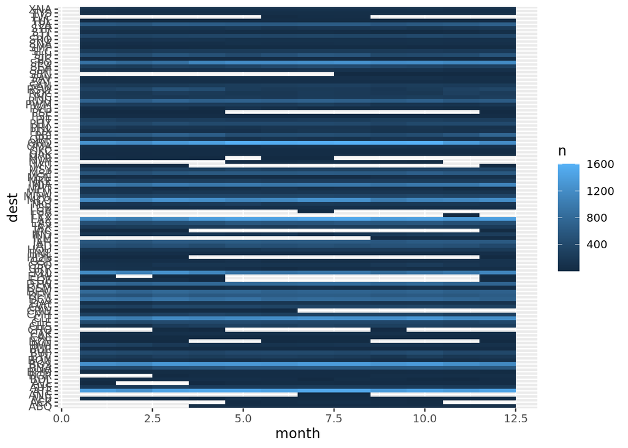

```r
flights %>%
  count(dest, month) %>%
  ggplot() +
  geom_tile(mapping = aes(x = month, y = dest, fill = n))
```

**3. Why is it slightly better to use aes(x = color, y = cut) rather than aes(x = cut, y = color) in the example above?**

Using the larger number of categories on the y-axis improves readability if the labels overlap when on the x-axis.